# Analysis of Sport Team Colors, Part 2

This write-up picks up where the previous one left off. All of the session data is carried over.

```r
# session::restore.session(file.path("data", "colors-eda-1.RData"))
load(file.path("data", "colors-eda-1.RData"))
# vars_all <- ls()
# vars_keep <- stringr::str_subset(vars_all, "^add_|^convert_|^lab_|^viz_*_base$|(colors_tidy_ord2)")
# rm(list = setdiff(vars_all, vars_keep))
library("dplyr")
library("ggplot2")
```

## Color Similarity

Now, I’d like to evaluate color similarity more closely. To help verify any quantitative deductions with some intuition, I’ll consider only a single league for this–the NBA, the league that I know the best.

Because I’ll end up plotting team names at some point (probably with a heat map), I want to get the official abbreviations for each team (because the full names are relatively lengthy). Unfortunately, these don’t come with the [`teamcolor` package](https://github.com/beanumber/teamcolors). Nevertheless, I can use [Alex Bresler](http://asbcllc.com/)’s [`nbastatR` package](https://github.com/abresler/nbastatR) to do so.

```r
# Assign `df_dict_nba_teams` to Global environment.
nbastatR::assign_nba_teams()
nms_nba <-
  teamcolors::teamcolors %>%
  filter(league == "nba") %>%
  inner_join(
    df_dict_nba_teams %>%
      setNames(snakecase::to_snake_case(names(.))) %>%
      filter(!is_non_nba_team) %>%
      select(name = name_team, slug = slug_team),
    by = c("name")
  )

colors_tidy_ord2_nba <-
  nms_nba %>%
  select(name, league, slug) %>%
  inner_join(colors_tidy_ord2, by = c("name", "league"))
```

To give the unfamiliar reader a better understanding of what exactly this subset of the `teamcolors` data incorporate, here’s a visualization of the primary and secondary colors of all NBA teams

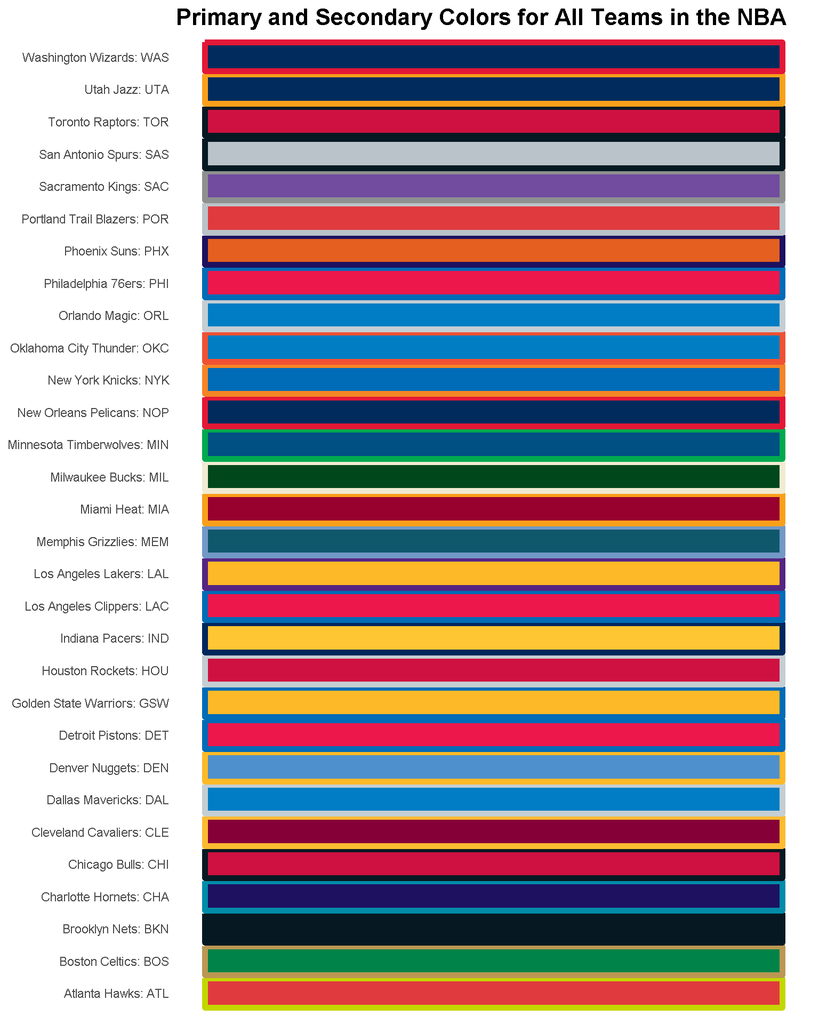

After grabbing the abbreviations (or `slug`s), I can move on to breaking up the hex values into their RGB components. (I use the same method as the one used before.) I’ll be looking at only the primary and secondary colors again.

```r
colors_ord2_nba_rgb_tidy <-
  colors_tidy_ord2_nba %>%
  add_rgb_cols() %>%
  select(-hex) %>%
  tidyr::gather(rgb, value, red, green, blue)

colors_ord2_nba_rgb_tidy %>%
  create_kable()
```

| name | league | slug | ord | rgb | value |
| --- | --- | --- | --- | --- | --- |
| Atlanta Hawks | nba | ATL | primary | red | 225 |
| Atlanta Hawks | nba | ATL | secondary | red | 196 |
| Boston Celtics | nba | BOS | primary | red | 0 |
| Boston Celtics | nba | BOS | secondary | red | 187 |
| Brooklyn Nets | nba | BKN | primary | red | 6 |
| Brooklyn Nets | nba | BKN | secondary | red | 6 |
| Charlotte Hornets | nba | CHA | primary | red | 29 |
| Charlotte Hornets | nba | CHA | secondary | red | 0 |
| Chicago Bulls | nba | CHI | primary | red | 206 |
| Chicago Bulls | nba | CHI | secondary | red | 6 |

<sup>1</sup> # of total rows: 180

```r
do_pairwise_dist <- function(data, method) {
  data %>%
    group_by(ord) %>%
    widyr::pairwise_dist(name, rgb, value, upper = TRUE, method = method) %>%
    rename(name1 = item1, name2 = item2) %>%
    select(everything(), value = ncol(.)) %>%
    arrange(value, .by_group = TRUE) %>%
    ungroup()
}

correlate_pairwise_out2 <- function(data1, data2) {
  corrr::correlate(
    data1 %>%
      rename(value1 = value) %>%
      left_join(data2 %>% rename(value2 = value)) %>%
      select_if(is.numeric)
  )
}

correlate_pairwise_out2(
  colors_ord2_nba_rgb_tidy %>%
    do_pairwise_dist("euclidean"),
  colors_ord2_nba_rgb_tidy %>%
    do_pairwise_dist("manhattan")
) %>%
  mutate_if(is.numeric, funs(convert_dec2pct)) %>%
  create_kable()
```

| rowname | value1 | value2 |
| --- | --- | --- |
| value1 | NA | 97.16 |
| value2 | 97.16 | NA |

As one might expect, there’s not much difference between these two distance methods (if correlation is deemed a valid metric for similarity). Some other distance methods would probably result in a more dissimilar result set, but these two methods seem most appropriate.

How exactly do all of the individual distances compare?

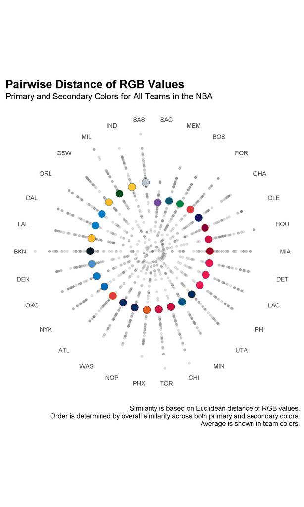

I think that this circular diagram does a good job of highlighting the average distance values (in terms of RGB) of each team. Additionally, by sorting the teams by value, it illustrates exactly which teams are the most “generic” (i.e. most similar to all other teams) and the most “unique” (i.e. least similar to all other teams.)

I can also use a heat map to visualize the distance values. (Who doesn’t like a good heat map?) Like with the previous plot, I order the teams on each axis by total distance from all other teams–teams with the highest cumulative similarity to all other teams appear towards the bottom and left, while teams that contrast most with all others appear towards the top and right. And, to add some nuance, I emphasize the individual team-pairs that have the highest and lowest similarity with different colors.

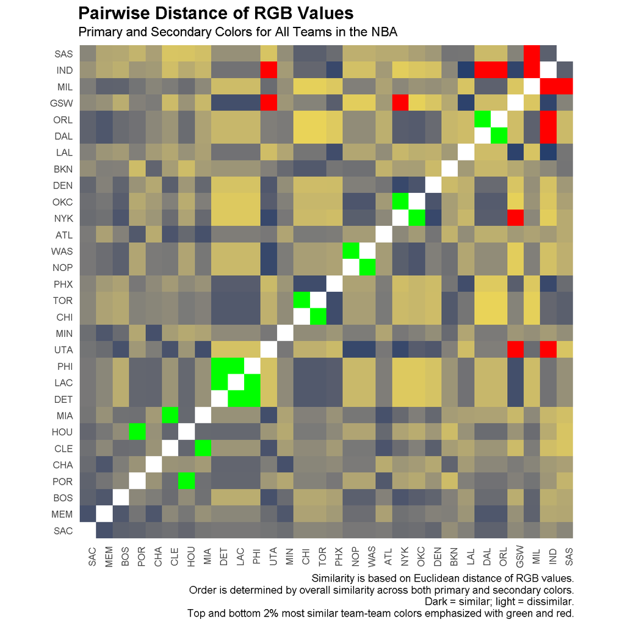

Exactly which teams make up the top and bottom percent (in terms of color similarity)? Here’s a list of the top and bottom 10. [^1]

| name1 | name2 | value |
| --- | --- | --- |
| Chicago Bulls | Toronto Raptors | 0.0000 |
| Dallas Mavericks | Orlando Magic | 0.0000 |
| Detroit Pistons | Los Angeles Clippers | 0.0000 |
| Detroit Pistons | Philadelphia 76ers | 0.0000 |
| Los Angeles Clippers | Detroit Pistons | 0.0000 |
| Los Angeles Clippers | Philadelphia 76ers | 0.0000 |
| New Orleans Pelicans | Washington Wizards | 0.0000 |
| Orlando Magic | Dallas Mavericks | 0.0000 |
| Philadelphia 76ers | Detroit Pistons | 0.0000 |
| Philadelphia 76ers | Los Angeles Clippers | 0.0000 |
| Indiana Pacers | Orlando Magic | 586.0178 |
| Orlando Magic | Indiana Pacers | 586.0178 |
| Golden State Warriors | New York Knicks | 586.1843 |
| New York Knicks | Golden State Warriors | 586.1843 |
| Golden State Warriors | Utah Jazz | 592.9791 |
| Utah Jazz | Golden State Warriors | 592.9791 |
| Indiana Pacers | Milwaukee Bucks | 617.1020 |
| Milwaukee Bucks | Indiana Pacers | 617.1020 |
| Milwaukee Bucks | San Antonio Spurs | 643.6029 |
| San Antonio Spurs | Milwaukee Bucks | 643.6029 |

These results don’t really agree with what I–and maybe other NBA fans–would have guessed. The Sacramento Kings (`SAC`) have purple as their primary color, which is relatively unusual. I would think that they would be in the lower half of these rankings. Whats going on? …

### Color Theory

Is the [RGB model](https://en.wikipedia.org/wiki/RGB_color_model) really the best framework to use for comparing colors? What about the [HSL color schema](https://en.wikipedia.org/wiki/HSL_and_HSV) (Hue, Saturation, Lightness), which incorporates hue and lightness (two concepts that I’ve looked at already)? While the HSL model is worth evaluating, my research on this topic–which mostly consisted of a quick Google search for [“What is the best method for identifying similarity between colors?”](https://stackoverflow.com/questions/5392061/algorithm-to-check-similarity-of-colors)–indicates that another encoding might be best–the [YUV representation](https://en.wikipedia.org/wiki/YUV).

Since’ I’m not expert in color models, I think its a good idea to perform distance calculations using each schema and see how well they agree with one another.

To begin, I’ll create “tidy” HSL and YUV data sets (using some custom functions that I do not show). Then, as a sort-of “sanity check”, I’ll verify that the similarity determined by two distance methods–Euclidean and Manhattan–is nearly identical for each data set (corresponding to a singular color model).

```r
colors_ord2_nba_hsl_tidy <-
  colors_tidy_ord2_nba %>%
  add_hsl_cols() %>%
  select(-hex) %>%
  tidyr::gather(rgb, value, h, s, l)

colors_ord2_nba_yuv_tidy <-
  colors_tidy_ord2_nba %>%
  add_yuv_cols() %>%
  select(-hex) %>%
  tidyr::gather(rgb, value, y, u, v)

correlate_pairwise_out2(
  colors_ord2_nba_hsl_tidy %>%
    do_pairwise_dist("euclidean"),
  colors_ord2_nba_hsl_tidy %>%
    do_pairwise_dist("manhattan")
) %>%
  mutate_if(is.numeric, funs(convert_dec2pct)) %>%
  create_kable()
```

| rowname | value1 | value2 |
| --- | --- | --- |
| value1 | NA | 97.62 |
| value2 | 97.62 | NA |

```r
correlate_pairwise_out2(
  colors_ord2_nba_yuv_tidy %>%
    do_pairwise_dist("euclidean"),
  colors_ord2_nba_yuv_tidy %>%
    do_pairwise_dist("manhattan")
) %>%
  mutate_if(is.numeric, funs(convert_dec2pct)) %>%
  create_kable()
```

| rowname | value1 | value2 |
| --- | --- | --- |
| value1 | NA | 96.26 |
| value2 | 96.26 | NA |

Now, when keeping the distance method constant, what if I compare the calculated values across the each underlying data set (corresponding to the different color models)?

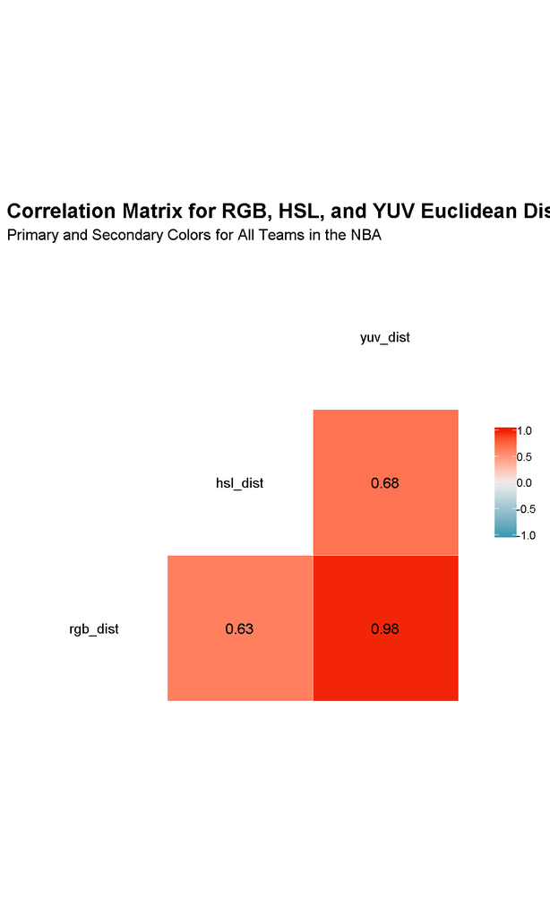

Even if one can decide upon a “best” color scheme to use for comparing colors, there is the question of whether “distance” is the best method for doing so. Why not a “similarity” metric (such as cosine similarity)?

Again, since I don’t really have a strong opinion on which metric is appropriate, I think it’s worthwhile to look at both. I’ll save the reader from the details–it’s not too dissimilar (pun intended) from the methods shown before– and skip right to a visualization showing the correlations among the distance metric (Euclidean method) and similarity metric for each color model–RGB, HSL, and YUV. (This presents a good opportunity to use [Dr. Simon](https://drsimonj.svbtle.com/)’s [`{corrr} package`](https://github.com/drsimonj/corrr), including its handy `network_plot()` function. (`GGally::ggcorr()` was used for the previous correlation plot).

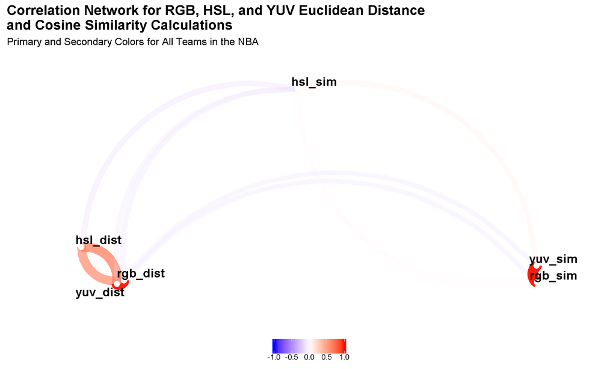

It’s clear that the RGB and YUV are fairly similar according to both metrics–Euclidean distance and cosine similarity–and both are relatively dissimilar to HSL. However, all three color models show negative correlations with themselves when comparing the two metrics.

*So, which color model and which metric should be used?* In my (uninformed) opinion, the RGB model seems like a good choice, both because it is relatively similar to at least one other method (YUV) and because it is (probably) the most relatable scheme to people who don’t know much about color theory. For metric, I think that the choice of Euclidean distance is very defensible. My Google search (which makes the case for YUV) makes the assumption that Euclidean distance is being used. Additionally, a second Google search for “euclidean distance vs. cosine similarity” turns up [an easy-to-follow technical write-up](https://cmry.github.io/notes/euclidean-v-cosine) that implies that cosine similarity is probably not really appropriate for this kind of color analysis.

## Conclusion

That’s all I got for this topic. I hope that the techniques shown here are general enough that they can be applied to any set of color to extract some fun (and meaningful) insight.

[^1]: There are some ties–these are broken by cumulative similarity rank (i.e. the metric shown in the previous plot), which is not shown in the data printout.